# HRS 2016 - Cognition classification

Authors

Affiliations

Douglas Tommet

Brown University, Department of Psychiatry and Human Behavior

Richard N. Jones

Brown University, Department of Psychiatry and Human Behavior, Department of Neurology

HRS/HCAP Team

Published

August 7, 2026

Abstract

**Objective:** Create a diagnostic algorithm in the HRS 2016 HCAP sample, and apply the algorithm to the HRS 2016-2022 waves.

# Mplus models

## Model 1

Sample HRS 2016, age 65+

Weights: HCAP16WGTR, participants not in HCAP get a weight of 0

Estimator: WLSMV N = 9218

Missing cognitive testing N=571

Fit statistics:

Table 1: Model 1: Fit statistics

| Fit statistic | Value |
| --- | --- |
| RMSEA : Estimate | 0.035 |
| CFI | 0.966 |
| SRMR | 0.047 |

Factor loadings:

Table 2: Model 1: Factor loadings

| Item | Label | Std Factor Loading |
| --- | --- | --- |
| vdori | Orientation to time | 0.517 |
| vdlfl1z | Animal naming | 0.631 |
| vdlfl2 | Scissors & cactus | 0.837 |
| vdlfl3 | President & vice-president | 0.637 |
| vdwddelz | Delayed word recall | 0.641 |
| vdexf7z | Number series | 0.618 |
| vdsevens | Serial sevens | 0.597 |
| vdcount | Count backwards from 20 | 0.562 |

## Model 1a

Sample HRS 2016, age 65+

Weights: HCAP16WGTR, participants not in HCAP get a weight of 0

Estimator: MLR-Probit

N = 9218

Missing cognitive testing N=571

Factor loadings:

Table 3: Model 1a: Factor loadings

| Item | Label | Std Factor Loading |
| --- | --- | --- |
| vdori | Orientation to time | 0.484 |
| vdlfl1z | Animal naming | 0.601 |
| vdlfl2 | Scissors & cactus | 0.683 |
| vdlfl3 | President & vice-president | 0.603 |
| vdwddelz | Delayed word recall | 0.629 |
| vdexf7z | Number series | 0.711 |
| vdsevens | Serial sevens | 0.655 |
| vdcount | Count backwards from 20 | 0.520 |

## Model 1a fixed

Model with all parameters fixed to those from Model 1a, and mean=0 and variance=1.

Estimator: MLR-Probit

N = 9218,

Missing cognitive testing N=571

Note: Everyone gets a factor score, even if they weren’t in HCAP

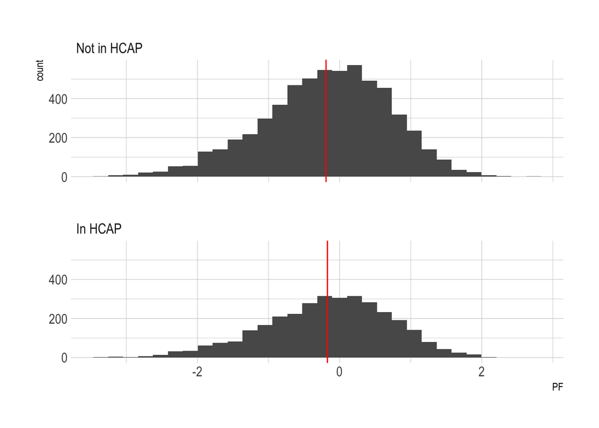

Figure 1: Distribution of factor scores by HCAP inclusion

## Blom transformation

This script derives a **normed, Blom-transformed version of the cognitive factor score (`PF`)** for the 2016 HRS HCAP data, using restricted cubic splines to flexibly model the relationship between the raw factor score and its normalized (Blom) rank, and then applies that model to the full 2016 sample and the 2016–2022 longitudinal sample.

| Object | Source file | Description |
| --- | --- | --- |
| `hrs16_merged` | `A7_050_hrs16_merged.rds` | Full 2016 HCAP merged dataset |
| `hrs16_22_long` | `A7_050_hrs16_22_long.rds` | Long-format 2016–2022 panel data |

### Step 1: Define the Normative Sample

- Restricts to respondents **not excluded from norming** (`normexcld == 0`).
- Creates a zero-filled version of the HCAP 2016 weight (`HCAP16WGTR0`), replacing `NA` weights with 0.

### Step 2: Build Restricted Cubic Spline Terms

A helper function, `factor_splines(df, q)`, computes a **3-term restricted cubic spline basis** for the factor score `PF`, given four knot locations `q`:

- `spF1` — linear term (equal to `PF` itself)
- `spF2`, `spF3` — nonlinear spline basis terms, computed with the standard restricted cubic spline (natural spline) formula using knots `k1`–`k4`
- Variable labels are attached to the three spline columns for documentation

Knots are set at the **5th, 35th, 65th, and 95th percentiles** of `PF` in the normative sample:

The spline basis is then generated for all three data frames, using the **same knots** derived from the norming sample:

- `hrs16_cog_norm` — the normative sample
- `hrs16_merged` — the full 2016 HCAP sample
- `hrs16_22_long` — the 2016–2022 long panel (temporarily renaming `F` to `PF` to reuse the function, then dropping `PF` afterward)

### Step 3: Blom Transform in the Normative Sample

- Computes the **Blom-transformed** (normal-scores) version of `PF` within the normative sample only, using `rcompanion::blom()`.

### Step 4: Fit and Apply the Norming Model

A linear model predicts the Blom-transformed score from the spline basis:

`F → Pblom`

This model — **fit only on the normative sample** — is then used to generate predicted (“normed”) Blom scores (`Pblom`) for **all three** data frames.

- `hrs16_cog_norm$Pblom`
- `hrs16_merged$Pblom`
- `hrs16_22_long$Pblom`

Each `Pblom` column is labelled: *“Predicted Blom score (model from HCAP normal sample)”*.

This approach effectively **norms the factor score against the HCAP normative sample**, allowing scores from the broader 2016 sample and the 2016–2022 panel to be expressed on the same normalized scale.

### Outputs

| Object | Saved to |
| --- | --- |
| `hrs16_cog_norm` | `A7_052_hrs16_cog_norm.rds` |
| `hrs16_merged` | `A7_052_hrs16_merged.rds` |
| `hrs16_22_long` | `A7_052_hrs16_22_long.rds` |

### Key Methodological Notes

- **Knots and model are derived solely from the normative sample** (`normexcld == 0`), then applied out-of-sample to the full 2016 data and the longitudinal panel — this is the core “norming” step.
- The restricted cubic spline uses a **3-degree-of-freedom** formulation (1 linear + 2 nonlinear terms) based on 4 knots, a standard approach (e.g., Harrell’s `rcs`) for flexibly modeling non-linear relationships while keeping tails linear.
- The **Blom transformation** converts the factor score to approximate normal scores (ranks transformed via the inverse normal CDF with the Blom correction), which is then predicted from the spline terms so it can be applied to samples outside the normative group.

## Converting 2016-2022 waves to ‘long’ data format

This script takes several groups of **wave-wide variables** from the merged 2016–2022 dataset, **pivots each group to long format** (one row per person-wave), and merges them onto the existing long-format panel `hrs16_22_long`.

The four HRS/HCAP wave letters used throughout are:

- **P** = 2016
- **Q** = 2018
- **R** = 2020
- **S** = 2022

| Object | Source file | Description |
| --- | --- | --- |
| `hrs16_22_long` | `A7_052_hrs16_22_long.rds` | Existing long-format 2016–2022 panel (one row per id-wave) |
| `hrs16_22_merged` | `A7_005_hrs16_22_merged.rds` | Wide-format merged dataset (one row per id, wave-prefixed columns) |

### Step 1: Pivot Simple “x” Variables

- Selects columns matching the pattern `x` + wave letter + single digit (e.g. `xP1`, `xQ2`, …).
- These are the demographic variables.
- Uses `pivot_longer()` with `.value` to split each column name into a **wave** (`P`/`Q`/`R`/`S`) and a **variable number** (`1`, `2`, …), creating one row per id-wave.
- Since `.value` pivoting drops the `x` prefix from the resulting column names, `rename_with()` re-adds the `x` prefix (e.g. resulting columns become `x1`, `x2`, …).

### Step 2: Pivot Interaction Variables

- Selects **interaction-term columns** with a double wave/number pattern (e.g. `xP1xP4`).
- These are the interaction between demographic variables.
- Renames each column from the raw format (`xP1xP4`) to a standardized format (`P_x1x4`), moving the wave letter to the front so it can be extracted during pivoting.
- Pivots to long format using `.value`, splitting each column into **wave** and the remaining interaction variable name (e.g. `x1x4`), producing one row per id-wave.

### Step 3: Merge Simple and Interaction Variables

Combines the reshaped simple `x` variables and interaction variables into a single long data frame keyed by `id` and `wave`.

### Step 4: Pivot the Jorm Cognitive Score

Reshapes the four wave-specific Jorm score columns (`rPjorm`, `rQjorm`, `rRjorm`, `rSjorm`) into a single `jorm` column with a `wave` identifier.

### Step 5: Pivot the D102 (Imputed) Variable

Reshapes the four wave-specific imputed `D102` columns into a single `D102_imp` column with a `wave` identifier.

### Step 6: Merge Everything into the Long Panel

Sequentially left-joins the three newly reshaped long data frames onto the existing `hrs16_22_long` panel, keyed by `id` and `wave`, adding the `x*` variables, interaction terms, `jorm` score, and `D102_imp` as new columns.

### Output

| Object | Saved to |
| --- | --- |
| `hrs16_22_long` | `A7_053_hrs16_22_long.rds` |

### Key Methodological Notes

- The core technique throughout is **wide-to-long reshaping with `tidyr::pivot_longer()` using the `.value` sentinel**, which lets a single call split column names into both an identifier (wave) and a variable name, avoiding manual loops over waves.
- Regex patterns (`names_pattern` / `matches()`) are used consistently to select and parse wave-prefixed or wave-embedded column names for the four HRS waves (P/Q/R/S).
- Column renaming (`rename_with()`, `str_replace_all()`) is used before pivoting when the wave identifier isn’t in a position `pivot_longer()` can parse directly (as with the interaction terms, where the wave letter needs to move to the front of the name).
- All reshaped pieces are joined back to the master long panel using the composite key `id` + `wave`, preserving one row per person per wave.

## Norming Factor Scores

This script builds a **survey-weighted regression model predicting the normed Blom factor score (`Pblom`) from demographic/interaction variables**, using the 2016 HCAP normative sample. It then applies that model to generate **demographically-adjusted expected scores (`Eblom`)** across all three data frames, and converts the residual (observed minus expected, standardized) into a **T-scaled score (`TF`, mean 50, SD 10)** — a common approach for producing norm-referenced cognitive scores adjusted for demographic characteristics.

| Object | Source file | Description |
| --- | --- | --- |
| `hrs16_cog_norm` | `A7_052_hrs16_cog_norm.rds` | Normative HCAP 2016 sample with `Pblom` |
| `hrs16_merged` | `A7_052_hrs16_merged.rds` | Full 2016 HCAP sample with `Pblom` |
| `hrs16_22_long` | `A7_053_hrs16_22_long.rds` | Long-format 2016–2022 panel |

### Step 1: Alias Wave-P (“2016”) Variables to Generic Names

- Both `hrs16_cog_norm` and `hrs16_merged` are **cross-sectional 2016 (wave P) data**, so their wave-P-prefixed variables (`xP1`…`xP7` and interaction terms like `xP1xP4`) are copied into generic, wave-agnostic names (`x1`…`x7`, `x1x4`, etc.).
- This lets the same model formula be applied consistently to the 2016 cross-sectional data and the long panel (`hrs16_22_long`), which already stores these variables under the generic `x*` names (from the earlier reshape in A7_053).

### Step 2: Fit the Demographic Model (Survey-Weighted)

- Defines the complex survey design (`SECU` primary sampling unit, `STRATUM` strata, `HCAP16WGTR0` weights) for the normative sample.
- Fits a **survey-weighted GLM** predicting `Pblom` from the seven main-effect demographic terms (`x1`–`x7`) and a set of pairwise interaction terms — fit **only on the normative sample**, mirroring the norming approach used for `Pblom` itself.

### Step 3: Predict Expected (“Eblom”) Scores in All Samples

- Uses the fitted model to generate **demographically-expected Blom scores (`Eblom`)** for the normative sample and the full 2016 sample.

For the long panel, predictions are generated on a **filtered subset** (rows with non-missing `x1`, i.e. rows with demographic data available) and then merged back:

- This avoids errors from `augment()`/`predict()` on rows with missing predictors, then reattaches `Eblom` by `id` + `wave`, leaving `NA` for waves without demographic data.

### Step 4: Compute R² and Residual SD for Standardization

- Computes a **pseudo-R²** for the survey GLM as `1 - deviance/null.deviance` (~0.366).
- Computes the **weighted standard deviation** of `Pblom` in the normative sample (~0.973) using `Hmisc::wtd.var()`.
- Combines these to get the **standardized residual SD** (~0.775), which is used as the scaling denominator in the T-score formula below.

### Step 5: Compute T-Scaled Residual Score (`TF`)

Applied identically to all three data frames:

- `TF` is a **T-score** (mean 50, SD 10) representing how far a person’s observed Blom score (`Pblom`) deviates from their demographically-expected score (`Eblom`), standardized by the residual SD.
- This produces a cognitive score that is **normed against the HCAP sample and adjusted for demographic characteristics** (age, sex, race/ethnicity, education).

### Outputs

| Object | Saved to |
| --- | --- |
| `hrs16_merged` | `A7_055_hrs16_merged.rds` |
| `hrs16_cog_norm` | `A7_055_hrs16_cog_norm.rds` |
| `hrs16_22_long` | `A7_055_hrs16_22_long.rds` |
| `foo_glm` (fitted model) | `A7_055_foo_lm.rds` |

### Key Methodological Notes

- The model is fit **only in the normative sample** using **survey weights and design**, consistent with proper norming methodology, then applied out-of-sample to the full 2016 data and the 2016–2022 panel — the same “fit-in-norm, apply-to-all” pattern used for the Blom transform in the prior script (A7_052).
- The wave-P variable aliasing step (Step 1) is necessary because the 2016 cross-sectional frames store demographic/interaction variables with a `xP*` prefix, while the long panel already uses generic `x*` names — aliasing lets one model formula work across all three data structures.
- `TF` is analogous to a **standardized residual T-score**: values above 50 indicate better-than-expected cognitive performance given demographics, values below 50 indicate worse-than-expected performance, in SD-of-10 units.
- Missing-data handling for the long panel (filtering to `!is.na(x1)` before prediction, then left-joining back) preserves all panel rows while avoiding prediction errors on waves lacking demographic covariates.

## Descriptive statistics of factor scores

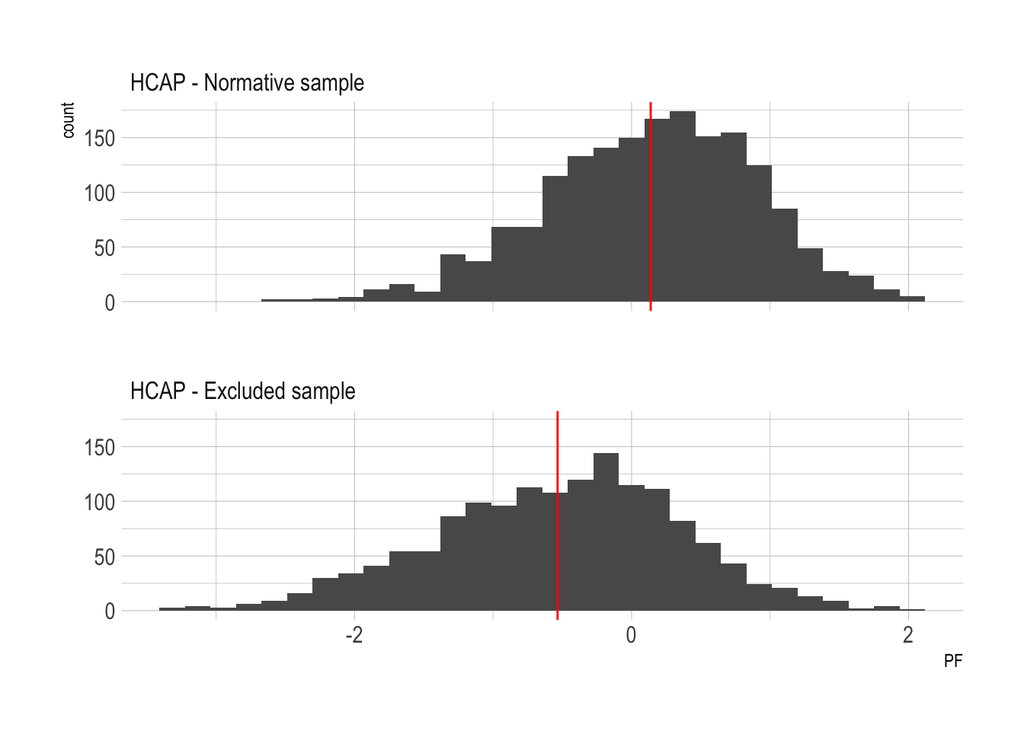

Figure 2: Distribution of factor scores by HCAP normative sample status

Table 4: Descriptive statistics of factor scores by HCAP normative sample status

| **Characteristic** | **Overall** N = 3,496 | **HCAP - Normative sample** N = 1,787 | **HCAP - Excluded sample** N = 1,709 |
| --- | --- | --- | --- |
| Factor score (2016) |  |  |  |
| Mean (SD) | -0.17 (0.88) | 0.14 (0.76) | -0.53 (0.88) |
| Median (Q1, Q3) | -0.11 (-0.74, 0.45) | 0.19 (-0.36, 0.70) | -0.47 (-1.12, 0.08) |
| Min, Max | -3.30, 2.04 | -2.60, 2.04 | -3.30, 2.01 |
| Unknown | 213 | 11 | 202 |

Table 5: Descriptive statistics of adjusted factor scores

| **Characteristic** | **Not in HCAP** N = 6,293 | **HCAP - Excluded sample** N = 1,709 | **HCAP - Normative sample** N = 1,787 |
| --- | --- | --- | --- |
| Predicted Blom score (model from HCAP normal sample) |  |  |  |
| Mean (SD) | -0.41 (1.12) | -0.84 (1.08) | 0.00 (1.00) |
| Median (Q1, Q3) | -0.40 (-1.13, 0.34) | -0.80 (-1.56, -0.14) | 0.00 (-0.68, 0.71) |
| Min, Max | -4.07, 4.06 | -4.07, 2.80 | -3.26, 2.85 |
| Unknown | 358 | 202 | 11 |
| Demographically-adjusted Blom score |  |  |  |
| Mean (SD) | -0.17 (0.68) | -0.34 (0.66) | 0.01 (0.62) |
| Median (Q1, Q3) | -0.13 (-0.56, 0.28) | -0.27 (-0.73, 0.10) | 0.02 (-0.37, 0.47) |
| Min, Max | -3.23, 3.56 | -2.82, 1.11 | -2.21, 1.15 |
| T-scaled F residual |  |  |  |
| Mean (SD) | 47 (12) | 43 (12) | 50 (10) |
| Median (Q1, Q3) | 47 (40, 54) | 44 (36, 51) | 50 (43, 56) |
| Min, Max | -25, 106 | -6, 87 | 13, 83 |
| Unknown | 358 | 202 | 11 |

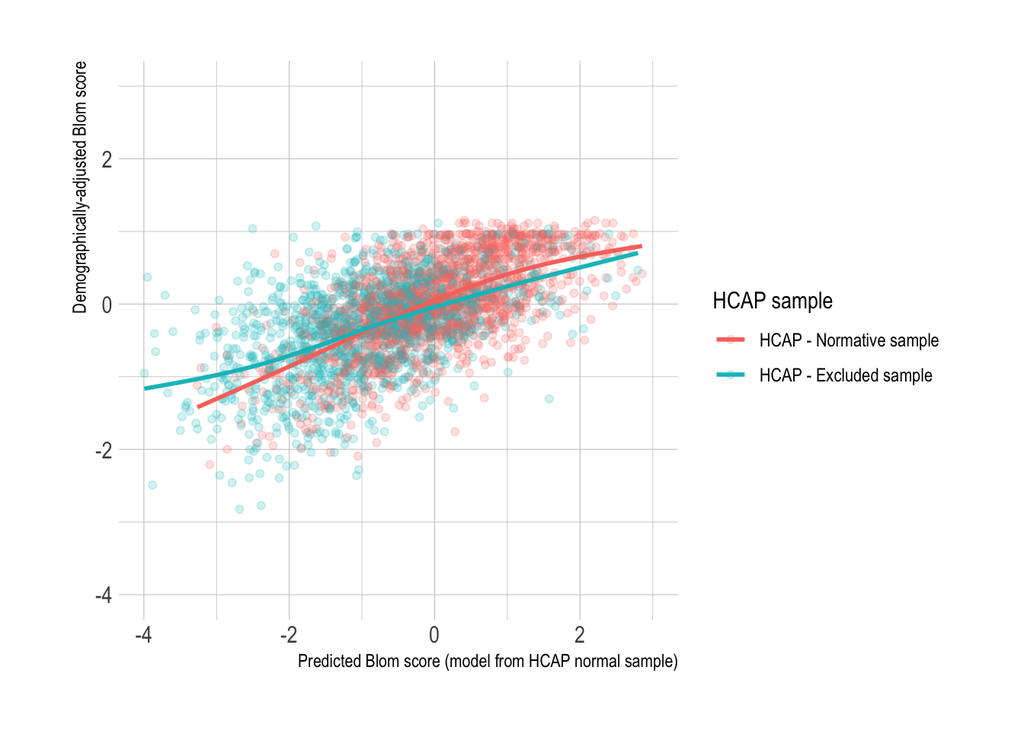

Figure 3: Demographically adjusted factor scores vs original factor score

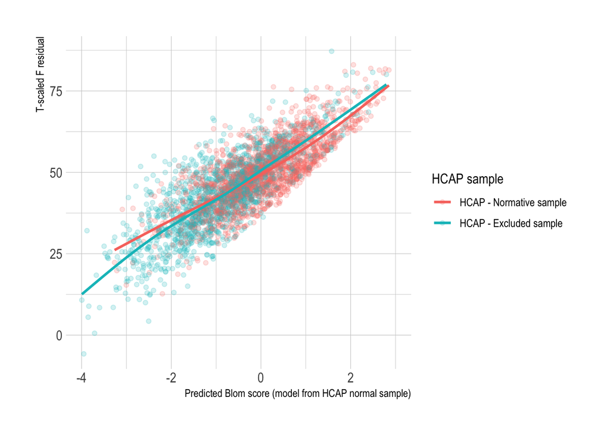

Figure 4: T-scaled factor residual vs original factor score

# Apply algorithm in the HCAP sample

This section descrbes a rule-based classification algorithm applied to the HCAP subsample to assign each respondent to one of three cognitive status categories: **Normal**, **MCI**, or **Dementia**. The algorithm combines a T-scaled cognitive performance score (`TF`), a self-reported memory change item (`PD102`), and an informant-rated cognitive change score (`jorm`). A flow diagram counting function is also defined to document how many respondents pass through each decision node. Both `algorithm_thresholds` and `v1_algorithm` are saved as function objects, allowing identical classification logic to be applied to future datasets without modifying code.

The HCAP subsample is extracted by filtering to `inHCAP == 1` (N = 3,496).

## Processing Steps

### 1. Threshold Classification (`algorithm_thresholds`)

Two intermediate threshold variables are computed before the final diagnosis is assigned.

#### `cog_threshold` — T-score Cognitive Performance Category

| Condition | `cog_threshold` | Interpretation |
| --- | --- | --- |
| `TF < 37` | 2 | Substantial impairment |
| `TF < 48` (and ≥ 37) | 1 | Mild impairment |
| `TF ≥ 48` | 0 | Normal range |

#### `jorm_threshold` — Informant-Rated Cognitive Change Category

| Condition | `jorm_threshold` | Interpretation |
| --- | --- | --- |
| `jorm ≥ 3.4` | 2 | Substantial worsening |
| `3.0 < jorm < 3.4` | 1 | Mild worsening |
| `jorm ≤ 3.0` | 0 | Stable or improved |

The JORM scale runs from 1 (much improved) to 5 (much worse); a score of 3.0 represents “not much change.”

#### Self-report memory change

The `PD102` values 8 (refused) and 9 (don’t know) are treated equivalently to 3 (worse) in the algorithm — ambiguous self-report responses are classified conservatively toward higher impairment.

The following code shows a function that uses these thresholds to create the data file.

```r
algorithm_thresholds
```

```
function (df)
{
    df <- df %>% mutate(cog_threshold = case_when(TF < 37 ~ 2,
        TF < 48 ~ 1, !is.na(TF) ~ 0), jorm_threshold = case_when(jorm >=
        3.4 ~ 2, jorm > 3 & jorm < 3.4 ~ 1, jorm <= 3 ~ 0))
    df
}
<bytecode: 0x33f0ac668>
```

### 2. V1 Classification Algorithm (`v1_algorithm`)

The final three-category diagnosis (`dx_v1`) is assigned using the following decision rules, applied in priority order. A visual of the algorithm is shown in Figure 5.

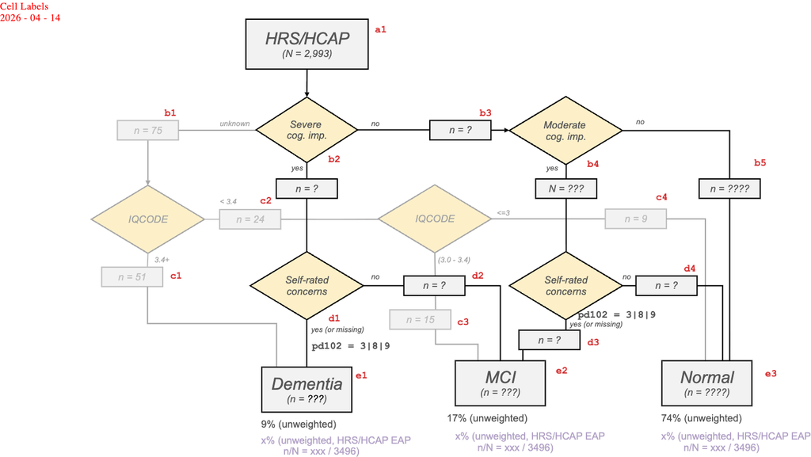

Figure 5: HRS algorithm (v1)

#### Primary Path — `TF` is Available

| `cog_threshold` | `PD102` | `dx_v1` | Label |
| --- | --- | --- | --- |
| 2 (substantial) | 3, 8, or 9 (worse/ambiguous) | 3 | Dementia |
| 2 (substantial) | 1 or 2 (same or better) | 2 | MCI |
| 1 (mild) | 3, 8, or 9 (worse/ambiguous) | 2 | MCI |
| 1 (mild) | 1 or 2 (same or better) | 1 | Normal |
| 0 (normal range) | Any | 1 | Normal |

The logic requires **both** a substantially low cognitive score **and** self-reported worsening to reach a dementia classification. A low score without self-reported worsening, or self-reported worsening with only mild cognitive impairment, results in MCI.

#### Fallback Path — `TF` is Missing

When `TF` is unavailable (e.g., proxy interviews or missing cognitive data), the JORM informant rating is used alone:

| `jorm_threshold` | `dx_v1` | Label |
| --- | --- | --- |
| 2 | 3 | Dementia |
| 1 | 2 | MCI |
| 0 | 1 | Normal |

This is the code that creates a function that implements the algorithm shown in Figure 5.

```r
v1_algorithm
```

```
function (df)
{
    df <- df %>% mutate(dx_v1 = case_when(cog_threshold == 2 &
        D102 %in% c(-8, 3, 8, 9) ~ 3, cog_threshold == 2 & D102 %in%
        c(1, 2) ~ 2, cog_threshold == 1 & D102 %in% c(-8, 3,
        8, 9) ~ 2, cog_threshold == 1 & D102 %in% c(1, 2) ~ 1,
        cog_threshold == 0 ~ 1, is.na(TF) & jorm_threshold ==
            2 ~ 3, is.na(TF) & jorm_threshold == 1 ~ 2, is.na(TF) &
            jorm_threshold == 0 ~ 1))
    df <- df %>% labelled::set_variable_labels(dx_v1 = "Algorithm (V1) Dx") %>%
        labelled::set_value_labels(dx_v1 = c(Normal = 1, MCI = 2,
            Dementia = 3))
    df
}
<bytecode: 0x33f101318>
```

Table 6: Relationship between algorithmic diagnosis and its constituent components

| Algorithm (V1) Dx | cog_threshold | RATE MEMORY PAST | jorm_threshold | n |
| --- | --- | --- | --- | --- |
| 1 | 0 | 1 | NA | 23 |
| 1 | 0 | 2 | NA | 1171 |
| 1 | 0 | 3 | NA | 366 |
| 1 | 1 | 1 | NA | 22 |
| 1 | 1 | 2 | NA | 802 |
| 1 | NA | NA | 0 | 69 |
| 2 | 1 | 3 | NA | 322 |
| 2 | 1 | 8 | NA | 3 |
| 2 | 2 | 1 | NA | 28 |
| 2 | 2 | 2 | NA | 345 |
| 2 | NA | NA | 1 | 37 |
| 3 | 2 | 3 | NA | 200 |
| 3 | 2 | 8 | NA | 1 |
| 3 | NA | NA | 2 | 107 |

### 3. Flow Diagram Counts (`v1_flow_diagram`)

A function computes the number of respondents at each decision node in the algorithm, returning a named list with 17 counts:

[output not shown]

## Descriptive statistics of classifications

Table 7: Distribution of dementia diagnoses in HCAP

| **Characteristic** | **N = 3,496**<sup>1</sup> |
| --- | --- |
| Algorithm (V1) Dx |  |
| Normal | 2,453 (70%) |
| MCI | 735 (21%) |
| Dementia | 308 (8.8%) |
| HRS HCAP Dementia and MCI Classification (EAP version, HRS HCAP variable set 1) |  |
| Normal (1) | 2,313 (66%) |
| MCI (2) | 808 (23%) |
| Dementia (3) | 375 (11%) |

<sup>1</sup> n (%)

Table 8: Crosstab of version 1 diagnosis and HCAP diagnosis

|  | Algorithm (V1) Dx Normal | Algorithm (V1) Dx MCI | Algorithm (V1) Dx Dementia | Total |  |
| --- | --- | --- | --- | --- | --- |
| HRS HCAP Dementia and MCI Classification (EAP version, HRS HCAP variable set 1) |  |  |  |  |  |
| Normal (1) | 1,955 | 306 | 52 | 2,313 |  |
| MCI (2) | 416 | 277 | 115 | 808 |  |
| Dementia (3) | 82 | 152 | 141 | 375 |  |
| Total | 2,453 | 735 | 308 | 3,496 |  |

```
$kappa
[1] 0.3276056

$weighted.kappa
[1] 0.5033945
```

Table 9: Distribution of dementia diagnoses in HCAP (Weighted)

| **Characteristic** | **N = 50,132,671**<sup>1</sup> |
| --- | --- |
| Algorithm (V1) Dx |  |
| 1 | 35,808,445 (71%) |
| 2 | 10,295,080 (21%) |
| 3 | 4,029,146 (8.0%) |
| HRS HCAP Dementia and MCI Classification (EAP version, HRS HCAP variable set 1) |  |
| 1 | 34,788,019 (69%) |
| 2 | 10,725,018 (21%) |
| 3 | 4,619,634 (9.2%) |

<sup>1</sup> n (%)

Table 10: Crosstab of version 1 diagnosis and HCAP diagnosis (Weighted)

| dx_v1 | HCAP Dementia and MCI Classification 1 | HCAP Dementia and MCI Classification 2 | HCAP Dementia and MCI Classification 3 |
| --- | --- | --- | --- |
| 1 | 29,359,567 | 5,534,282 | 914,596 |
| 2 | 4,698,006 | 3,656,102 | 1,940,972 |
| 3 | 730,446 | 1,534,634 | 1,764,066 |

```
$kappa
[1] 0.32398

$weighted.kappa
[1] 0.5051394
```

# Weighted Comparison Tables

Comparisons that involve the consensus diagnosis use the HRS/HCAP validation-subsample weights computed as `HCAP16WGTR * samplingP^(-1)`.

Comparisons that do not involve the consensus diagnosis use the HCAP population weights `HCAP16WGTR`.

### Langa-Weir versus Consensus panel

Table 11: Langa-Weir diagnosis vs Consensus panel diagnosis, with consensus-panel sample weights

| Langa-Weir classification | Consensus panel diagnosis Normal | Consensus panel diagnosis MCI | Consensus panel diagnosis Dementia | Total |  |
| --- | --- | --- | --- | --- | --- |
| Normal | 34 | 20 | 1 |  | 55 |
| MCI | 35 | 6 | 1 | 41 |  |
| Dementia | 0 | 1 | 3 | 4 |  |
| Total | 69 | 26 | 5 | 100 |  |

Note: This comparison uses the HRS/HCAP validation subsample. Weights are computed as HCAP16WGTR * samplingP^(-1) and are normalized within the consensus sample.

The quadratic weighted kappa is 0.099.

### Algorithmic diagnosis versus Consensus panel

Table 12: Algorithmic diagnosis vs Consensus panel diagnosis, with consensus-panel sample weights

| Algorithmic diagnosis | Consensus panel diagnosis Normal | Consensus panel diagnosis MCI | Consensus panel diagnosis Dementia | Total |  |
| --- | --- | --- | --- | --- | --- |
| Normal | 69 | 14 | 0 |  | 82 |
| MCI | 0 | 7 | 0 | 7 |  |
| Dementia | 0 | 6 | 4 | 11 |  |
| Total | 69 | 26 | 5 | 100 |  |

Note: This comparison uses the HRS/HCAP validation subsample. Weights are computed as HCAP16WGTR * samplingP^(-1) and are normalized within the consensus sample.

The quadratic weighted kappa is 0.728.

### HRS classification model versus Consensus panel

Table 13: Consensus panel diagnosis vs HRS classification model, with consensus-panel sample weights

| Consensus panel diagnosis | HRS classification model Normal | HRS classification model MCI | HRS classification model Dementia | Total |  |
| --- | --- | --- | --- | --- | --- |
| Normal | 46 | 23 | 0 |  | 69 |
| MCI | 18 | 9 | 0 | 26 |  |
| Dementia | 0 | 2 | 2 | 4 |  |
| Total | 64 | 34 | 2 | 100 |  |

Note: This comparison uses the HRS/HCAP validation subsample. Weights are the consensus-sample weights HCAP16WGTR * samplingP^(-1), normalized within the consensus sample.

The quadratic weighted kappa is 0.284.

### Hudomiet versus Consensus panel

Table 14: Consensus panel diagnosis vs Hudomiet, with consensus-panel sample weights

| Consensus panel diagnosis | Hudomiet Normal | Hudomiet MCI | Hudomiet Dementia | Total |  |
| --- | --- | --- | --- | --- | --- |
| Normal | 42 | 27 | 0 |  | 69 |
| MCI | 12 | 15 | 0 | 26 |  |
| Dementia | 0 | 1 | 4 | 5 |  |
| Total | 53 | 43 | 4 | 100 |  |

The quadratic weighted kappa is 0.396.

### Langa-Weir versus Algorithmic diagnosis

Table 15: Langa-Weir diagnosis vs Algorithmic diagnosis, with HCAP weights

| Algorithmic diagnosis | Langa-Weir diagnosis Normal | Langa-Weir diagnosis MCI | Langa-Weir diagnosis Dementia | Total |  |
| --- | --- | --- | --- | --- | --- |
| Normal | 30,246,474 | 4,091,218 | 450,327 |  | 34,788,019 |
| MCI | 6,069,690 | 3,120,130 | 1,535,198 | 10,725,018 |  |
| Dementia | 1,219,788 | 1,439,211 | 1,960,635 | 4,619,634 |  |
| Total | 37,535,952 | 8,650,559 | 3,946,160 | 50,132,671 |  |

Note: This comparison uses the HCAP sample. Weights are the HCAP population weights HCAP16WGTR. This weighting differs from the weighting used for tables involving the consensus diagnosis.

The quadratic weighted kappa is 0.51.

### HRS classification model versus Algorithmic diagnosis

Table 16: Algorithmic diagnosis vs HRS classification model, with HCAP weights

| Algorithmic diagnosis | HRS classification model Normal | HRS classification model MCI | HRS classification model Dementia | Total |  |
| --- | --- | --- | --- | --- | --- |
| Normal | 29,359,567 | 4,698,006 | 730,446 |  | 34,788,019 |
| MCI | 5,534,282 | 3,656,102 | 1,534,634 | 10,725,018 |  |
| Dementia | 914,596 | 1,940,972 | 1,764,066 | 4,619,634 |  |
| Total | 35,808,445 | 10,295,080 | 4,029,146 | 50,132,671 |  |

Note: This comparison uses the HCAP sample. The table weights are the HCAP population weights HCAP16WGTR.

The quadratic weighted kappa is 0.505.

### Hudomiet model versus Algorithmic diagnosis

Table 17: Algorithmic diagnosis vs Hudomiet, with HCAP weights

| Algorithmic diagnosis | Hudomiet Normal | Hudomiet MCI | Hudomiet Dementia | Total |  |
| --- | --- | --- | --- | --- | --- |
| Normal | 29,349,316 | 4,757,724 | 381,251 |  | 34,488,291 |
| MCI | 5,534,439 | 3,996,754 | 1,175,113 | 10,706,306 |  |
| Dementia | 783,158 | 1,750,550 | 2,055,534 | 4,589,242 |  |
| Total | 35,666,913 | 10,505,028 | 3,611,898 | 49,783,839 |  |

The quadratic weighted kappa is 0.551.

### Langa-Weir versus HRS classification model

Table 18: Langa-Weir diagnosis vs HRS classification model, with HCAP weights

| Langa-Weir classification | HRS classification model Normal | HRS classification model MCI | HRS classification model Dementia | Total |  |
| --- | --- | --- | --- | --- | --- |
| Normal | 31,645,284 | 5,099,636 | 791,032 |  | 37,535,952 |
| MCI | 3,521,173 | 3,836,944 | 1,292,442 | 8,650,559 |  |
| Dementia | 641,988 | 1,358,500 | 1,945,672 | 3,946,160 |  |
| Total | 35,808,445 | 10,295,080 | 4,029,146 | 50,132,671 |  |

Note: This comparison uses the HCAP sample. The table weights are the HCAP population weights HCAP16WGTR.

The quadratic weighted kappa is 0.561.

### Langa-Weir versus Hudomiet

Table 19: Langa-Weir diagnosis vs Hudomiet, with HCAP weights

| Langa-Weir classification | Hudomiet Normal | Hudomiet MCI | Hudomiet Dementia | Total |  |
| --- | --- | --- | --- | --- | --- |
| Normal | 32,711,158 | 4,203,746 | 290,928 |  | 37,205,832 |
| MCI | 2,797,021 | 5,140,333 | 694,493 | 8,631,847 |  |
| Dementia | 158,734 | 1,160,949 | 2,626,477 | 3,946,160 |  |
| Total | 35,666,913 | 10,505,028 | 3,611,898 | 49,783,839 |  |

The quadratic weighted kappa is 0.717.

### HRS classification model versus Hudomiet

Table 20: HRS classification model vs Hudomiet, with HCAP weights

| HRS classification model | Hudomiet Normal | Hudomiet MCI | Hudomiet Dementia | Total |  |
| --- | --- | --- | --- | --- | --- |
| Normal | 30,816,529 | 4,261,086 | 515,125 |  | 35,592,740 |
| MCI | 4,435,377 | 4,593,422 | 1,133,154 | 10,161,953 |  |
| Dementia | 415,007 | 1,650,520 | 1,963,619 | 4,029,146 |  |
| Total | 35,666,913 | 10,505,028 | 3,611,898 | 49,783,839 |  |

The quadratic weighted kappa is 0.603.

### Agreement Matrix

Table 21: Pairwise quadratic weighted kappa matrix using consensus-panel weights for consensus comparisons and HCAP weights otherwise

| Consensus sample | Consensus diagnosis | Algorithmic diagnosis | Langa-Weir | HRS classification model | Hudomiet |
| --- | --- | --- | --- | --- | --- |
| Consensus diagnosis | 1.000 | 0.728 | 0.099 | 0.284 | 0.396 |
| Algorithmic diagnosis | 0.728 | 1.000 | 0.510 | 0.505 | 0.551 |
| Langa-Weir | 0.099 | 0.510 | 1.000 | 0.561 | 0.717 |
| HRS classification model | 0.284 | 0.505 | 0.561 | 1.000 | 0.603 |
| Hudomiet | 0.396 | 0.551 | 0.717 | 0.603 | 1.000 |

Note: This matrix combines pairwise quadratic weighted kappas computed under different weighting schemes. Entries involving the consensus diagnosis use consensus-sample weights HCAP16WGTR * samplingP^(-1), normalized within the validation subsample. Entries not involving the consensus diagnosis use HCAP population weights HCAP16WGTR.

## Dementia Versus Non-dementia

This section collapses Normal and MCI into a single non-demented category. Comparisons that involve the consensus diagnosis use consensus-panel weights, and comparisons that do not involve the consensus diagnosis use HCAP weights.

### Algorithmic diagnosis versus Consensus panel

Table 22: Algorithmic dementia classification vs Consensus panel diagnosis, with consensus-panel sample weights

| Algorithmic diagnosis | Consensus panel diagnosis Non-demented | Consensus panel diagnosis Demented | Total |  |
| --- | --- | --- | --- | --- |
| Non-demented | 89 | 0 |  | 89 |
| Demented | 6 | 4 | 11 |  |
| Total | 95 | 5 | 100 |  |

Note: This comparison uses the HRS/HCAP validation subsample. Weights are computed as HCAP16WGTR * samplingP^(-1) and are normalized within the consensus sample.

The kappa is 0.536.

### Langa-Weir versus Consensus panel

Table 23: Langa-Weir dementia classification vs Consensus panel diagnosis, with consensus-panel sample weights

| Langa-Weir classification | Consensus panel diagnosis Non-demented | Consensus panel diagnosis Demented | Total |  |
| --- | --- | --- | --- | --- |
| Non-demented | 95 | 2 |  | 96 |
| Demented | 1 | 3 | 4 |  |
| Total | 95 | 5 | 100 |  |

Note: This comparison uses the HRS/HCAP validation subsample. Weights are computed as HCAP16WGTR * samplingP^(-1) and are normalized within the consensus sample.

The kappa is 0.736.

### HRS classification model versus Consensus panel

Table 24: Consensus panel dementia classification vs HRS classification model, with consensus-panel sample weights

| Consensus panel diagnosis | HRS classification model Non-demented | HRS classification model Demented | Total |  |
| --- | --- | --- | --- | --- |
| Non-demented | 95 | 0 |  | 95 |
| Demented | 2 | 2 | 4 |  |
| Total | 97 | 2 | 100 |  |

Note: This comparison uses the HRS/HCAP validation subsample. Weights are the consensus-sample weights HCAP16WGTR * samplingP^(-1), normalized within the consensus sample.

The kappa is 0.675.

### Hudomiet versus Consensus panel

Table 25: Consensus panel dementia classification vs Hudomiet, with consensus-panel sample weights

| Consensus panel diagnosis | Hudomiet Non-demented | Hudomiet Demented | Total |  |
| --- | --- | --- | --- | --- |
| Non-demented | 95 | 0 |  | 95 |
| Demented | 1 | 4 | 5 |  |
| Total | 96 | 4 | 100 |  |

The kappa is 0.806.

### Langa-Weir versus Algorithmic diagnosis

Table 26: Langa-Weir dementia classification vs Algorithmic diagnosis, with HCAP weights

| Algorithmic diagnosis | Langa-Weir diagnosis Non-demented | Langa-Weir diagnosis Demented | Total |  |
| --- | --- | --- | --- | --- |
| Non-demented | 43,527,512 | 1,985,525 |  | 45,513,037 |
| Demented | 2,658,999 | 1,960,635 | 4,619,634 |  |
| Total | 46,186,511 | 3,946,160 | 50,132,671 |  |

Note: This comparison uses the HCAP sample. Weights are the HCAP population weights HCAP16WGTR. This weighting differs from the weighting used for tables involving the consensus diagnosis.

The kappa is 0.407.

### HRS classification model versus Algorithmic diagnosis

Table 27: Algorithmic dementia classification vs HRS classification model, with HCAP weights

| Algorithmic diagnosis | HRS classification model Non-demented | HRS classification model Demented | Total |  |
| --- | --- | --- | --- | --- |
| Non-demented | 43,247,957 | 2,265,080 |  | 45,513,037 |
| Demented | 2,855,568 | 1,764,066 | 4,619,634 |  |
| Total | 46,103,525 | 4,029,146 | 50,132,671 |  |

Note: This comparison uses the HCAP sample. The table weights are the HCAP population weights HCAP16WGTR.

The kappa is 0.352.

### Hudomiet versus Algorithmic diagnosis

Table 28: Algorithmic dementia classification vs Hudomiet, with HCAP weights

| Algorithmic diagnosis | Hudomiet Non-demented | Hudomiet Demented | Total |  |
| --- | --- | --- | --- | --- |
| Non-demented | 43,638,233 | 1,556,364 |  | 45,194,597 |
| Demented | 2,533,708 | 2,055,534 | 4,589,242 |  |
| Total | 46,171,941 | 3,611,898 | 49,783,839 |  |

Note: This comparison uses the HCAP sample. The table weights are the HCAP population weights HCAP16WGTR.

The kappa is 0.457.

### Langa-Weir versus HRS classification model

Table 29: Langa-Weir dementia classification vs HRS classification model, with HCAP weights

| Langa-Weir classification | HRS classification model Non-demented | HRS classification model Demented | Total |  |
| --- | --- | --- | --- | --- |
| Non-demented | 44,103,037 | 2,083,474 |  | 46,186,511 |
| Demented | 2,000,488 | 1,945,672 | 3,946,160 |  |
| Total | 46,103,525 | 4,029,146 | 50,132,671 |  |

Note: This comparison uses the HCAP sample. The table weights are the HCAP population weights HCAP16WGTR.

The kappa is 0.444.

### Langa-Weir versus Hudomiet

Table 30: Langa-Weir dementia classification vs Hudomiet, with HCAP weights

| Langa-Weir classification | Hudomiet Non-demented | Hudomiet Demented | Total |  |
| --- | --- | --- | --- | --- |
| Non-demented | 44,852,258 | 985,421 |  | 45,837,679 |
| Demented | 1,319,683 | 2,626,477 | 3,946,160 |  |
| Total | 46,171,941 | 3,611,898 | 49,783,839 |  |

Note: This comparison uses the HCAP sample. The table weights are the HCAP population weights HCAP16WGTR.

The kappa is 0.67.

### HRS classification model versus Hudomiet

Table 31: HRS classification model vs Hudomiet, with HCAP weights

| HRS classification model | Hudomiet Non-demented | Hudomiet Demented | Total |  |
| --- | --- | --- | --- | --- |
| Non-demented | 44,106,414 | 1,648,279 |  | 45,754,693 |
| Demented | 2,065,527 | 1,963,619 | 4,029,146 |  |
| Total | 46,171,941 | 3,611,898 | 49,783,839 |  |

Note: This comparison uses the HCAP sample. The table weights are the HCAP population weights HCAP16WGTR.

The kappa is 0.474.

### Binary Agreement Matrix

Table 32: Pairwise kappa matrix for dementia versus non-dementia using consensus-panel weights for consensus comparisons and HCAP weights otherwise

| Consensus sample | Consensus diagnosis | Algorithmic diagnosis | Langa-Weir | HRS classification model | Hudomiet |
| --- | --- | --- | --- | --- | --- |
| Consensus diagnosis | 1.000 | 0.536 | 0.736 | 0.675 | 0.806 |
| Algorithmic diagnosis | 0.536 | 1.000 | 0.407 | 0.352 | 0.457 |
| Langa-Weir | 0.736 | 0.407 | 1.000 | 0.444 | 0.670 |
| HRS classification model | 0.675 | 0.352 | 0.444 | 1.000 | 0.474 |
| Hudomiet | 0.806 | 0.457 | 0.670 | 0.474 | 1.000 |

Note: This matrix combines pairwise kappas for dementia versus non-dementia computed under different weighting schemes. Entries involving the consensus diagnosis use consensus-sample weights HCAP16WGTR * samplingP^(-1), normalized within the validation subsample. Entries not involving the consensus diagnosis use HCAP population weights HCAP16WGTR.